# Analysis logbook - experiment 2

Alexandre Nobre

2024-03-27

Este documento detalha as estratégias de seleção de modelos para as análises com modelos mistos.

# 0. Funções

Inicialmente criamos as funções utilizadas para comparar os modelos: uma função para construir histogramas bonitos e uma função para construir tabelas com estatísticas de ajuste.

```r
hist_resid <- function(M,ptitle='Residuals') {
  d <- data.frame(resid=residuals(M))
  d  %>% ggplot(aes(x=resid)) +
    geom_histogram(aes(y=after_stat(density)), bins=75, color='black', fill='grey') +
    geom_density(color='darkred') +
    ggtitle(ptitle) -> pl
  return(pl)
}

fitstats = function(M,mname='M') {
  QQ<-qqnorm(residuals(M), plot.it=FALSE)
  R2qq <- cor(QQ$x,QQ$y)^2
  dfqq = data.frame(stat='R2qq', V1=R2qq)
  r2tab <- r.squaredGLMM(M)  %>%
    t  %>% as.data.frame  %>% rownames_to_column(var='stat')  %>%
    rbind(.,dfqq)
  r2tab$stat = c("$R^2_m$","$R^2_c$",'$R^2_{qq}$' )
  colnames(r2tab) <- c('stat',mname)
  return(r2tab)
}
```

# 1. Seleção das variáveis dependentes

Para estes modelos, inicialmente fazemos a seleção das variáveis dependentes. A seleção é feita comparando-se os ajustes de modelos mistos com cada variável dependente, incluindo como apenas o intercepto como modelo aleatório. Os valores de ajuste utilizados são:

- Variância explicada pelos efeitos fixos
- Variância explicada pelo modelo completo
- Normalidade dos resíduos
- Correlação entre valores ajustados pelo modelo e dados

As variáveis comparadas são:

- RT bruto
- 1/RT
- log10(RT)

```r
# Fit models with RT, inverse RT, and logRT without trimming
fplmm1 <- mixed(formula = RT ~ foreperiod*condition*oneBackFP +
                  (1|participant),
                data = data,
                control = lmerControl(optimizer = c("bobyqa"),optCtrl=list(maxfun=2e5),calc.derivs = FALSE),
                progress = TRUE,
                expand_re = TRUE,
                method =  'S',
                REML=TRUE,
                return = "merMod")

invfplmm1 <- mixed(formula = invRT ~ foreperiod*condition*oneBackFP +
                     (1|participant),
                   data = data,
                   control = lmerControl(optimizer = c("bobyqa"),optCtrl=list(maxfun=2e5),calc.derivs = FALSE),
                   progress = TRUE,
                   expand_re = TRUE,
                   method =  'S',
                   REML=TRUE,
                   return = "merMod")

logfplmm1 <- mixed(formula = logRT ~ foreperiod*condition*oneBackFP +
                     (1|participant),
                   data = data,
                   control = lmerControl(optimizer = c("bobyqa"),optCtrl=list(maxfun=2e5),calc.derivs = FALSE),
                   progress = TRUE,
                   expand_re = TRUE,
                   method =  'S',
                   REML=TRUE,
                   return = "merMod")

# Now fit models after outlier trimming
trimfplmm1 <- mixed(formula = RT ~ foreperiod*condition*oneBackFP +
                      (1|participant),
                    data = data2,
                    control = lmerControl(optimizer = c("bobyqa"),optCtrl=list(maxfun=2e5),calc.derivs = FALSE),
                    progress = TRUE,
                    expand_re = TRUE,
                    method =  'S',
                    REML=TRUE,
                    return = "merMod")

triminvfplmm1 <- mixed(formula = invRT ~ foreperiod*condition*oneBackFP +
                         (1|participant),
                       data = data2,
                       control = lmerControl(optimizer = c("bobyqa"),optCtrl=list(maxfun=2e5),calc.derivs = FALSE),
                       progress = TRUE,
                       expand_re = TRUE,
                       method =  'S',
                       REML=TRUE,
                       return = "merMod")

trimlogfplmm1 <- mixed(formula = logRT ~ foreperiod*condition*oneBackFP +
                         (1|participant),
                       data = data2,
                       control = lmerControl(optimizer = c("bobyqa"),optCtrl=list(maxfun=2e5),calc.derivs = FALSE),
                       progress = TRUE,
                       expand_re = TRUE,
                       method =  'S',
                       REML=TRUE,
                       return = "merMod")
```

Antes de olhar valores de ajuste, vamos olhar se algum dos modelos resultou em um ajuste singular, indicando que não foi possível ajustar o modelo com as configurações e a estrutura escolhida.

```r
isSingular(fplmm1)
```

```
## [1] FALSE
```

```r
isSingular(invfplmm1)
```

```
## [1] FALSE
```

```r
isSingular(logfplmm1)
```

```
## [1] FALSE
```

```r
isSingular(trimfplmm1)
```

```
## [1] FALSE
```

```r
isSingular(triminvfplmm1)
```

```
## [1] FALSE
```

```r
isSingular(trimlogfplmm1)
```

```
## [1] FALSE
```

Nenhum dos modelos gerou um ajuste singular, então podemos continuar a comparação. Primeiro, elaboramos uma tabela com os valores de ajuste utilizados para a comparação.

| stat | RT | 1/(RT) | log(RT) | trim RT | trim 1/(RT) | trim log(RT) |
| --- | --- | --- | --- | --- | --- | --- |
| $R^2_m$ | 0.0238 | 0.0208 | 0.0230 | 0.0216 | 0.0190 | 0.0209 |
| $R^2_c$ | 0.4477 | 0.4646 | 0.4661 | 0.4728 | 0.4798 | 0.4854 |
| $R^2_{qq}$ | 0.9482 | 0.9906 | 0.9911 | 0.9620 | 0.9908 | 0.9955 |

Além de comparar os valores das estatísticas diretamente, plotamos os resíduos em histogramas, qqplots e gráficos de dispersão com os resíduos e os valores ajustados.

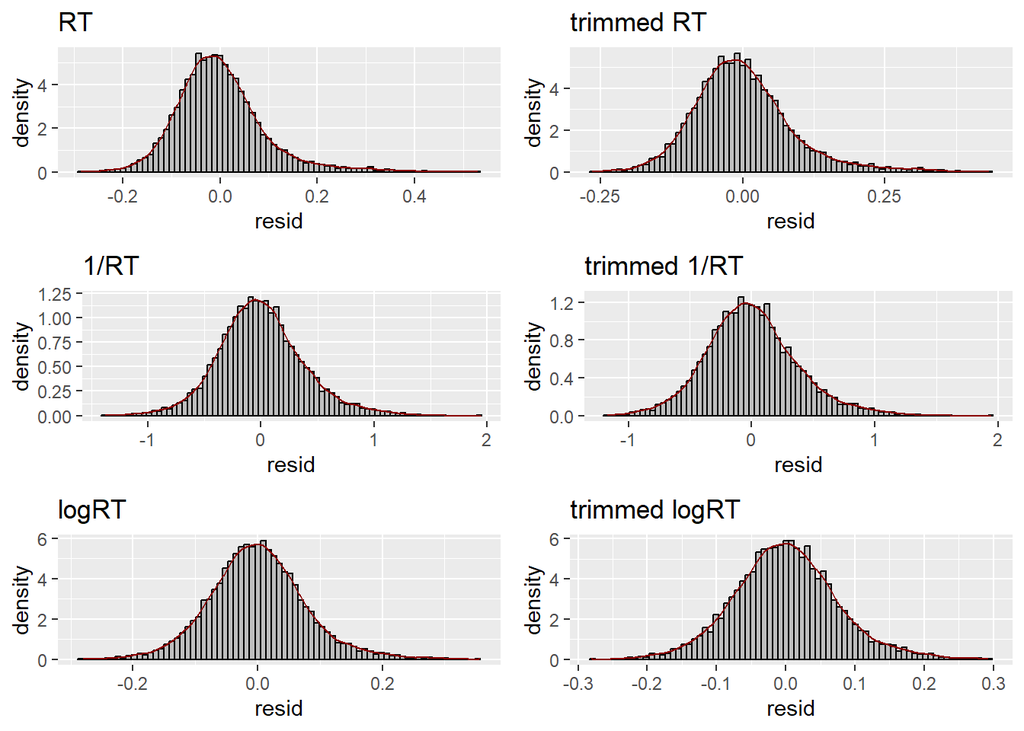

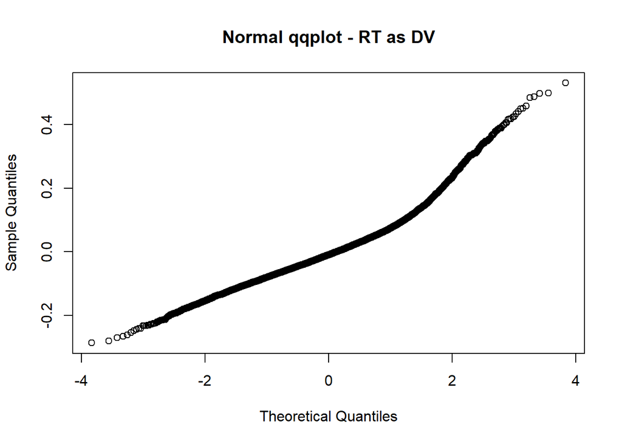

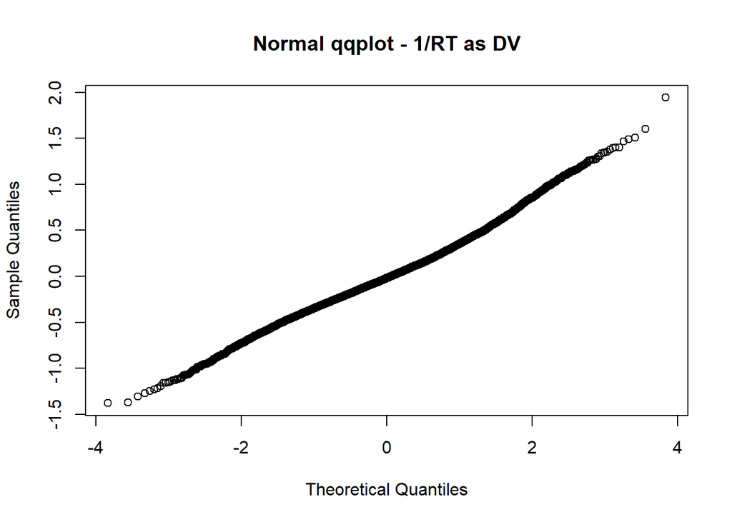

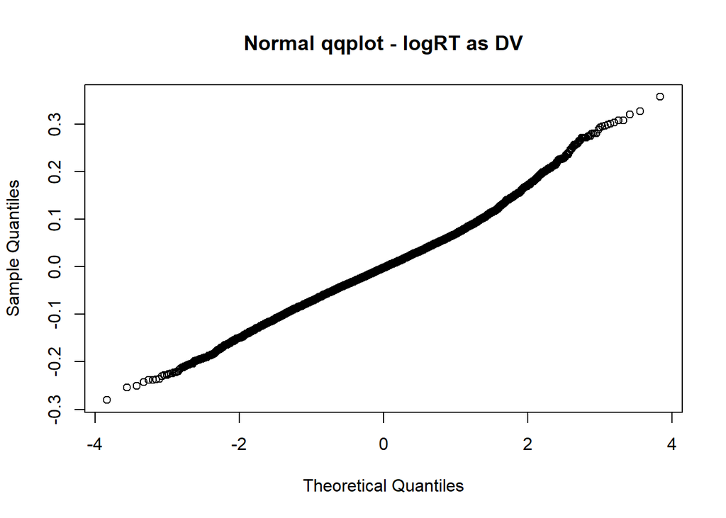

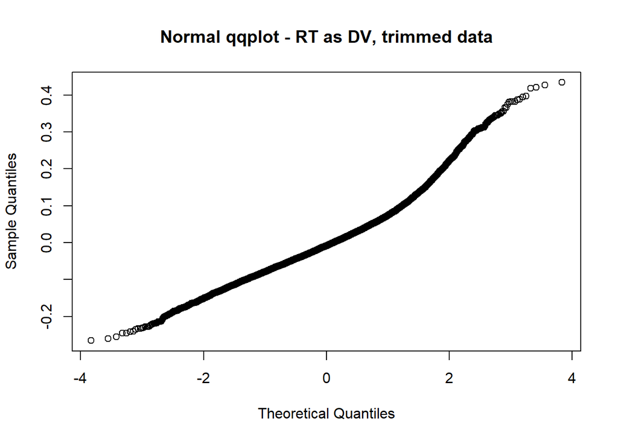

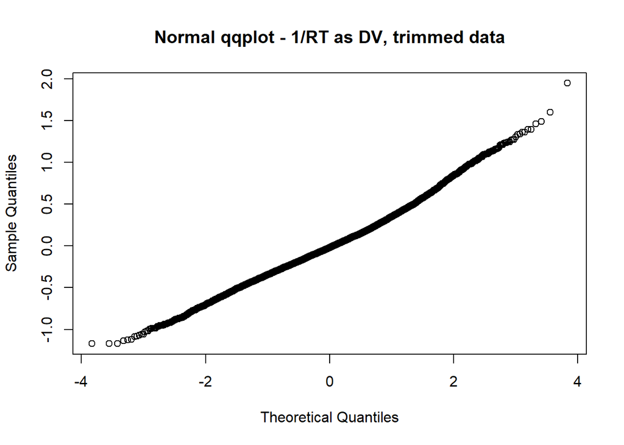

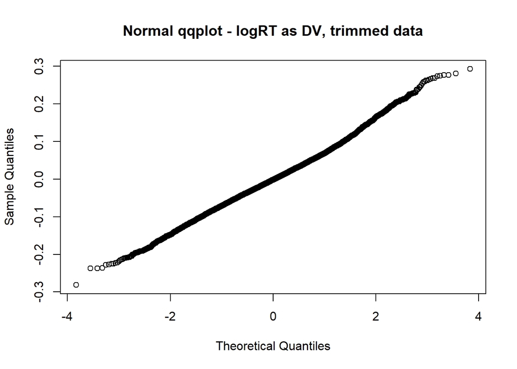

Os modelos com logRT resultam em resíduos mais próximos da normalidade, e isso é especialmente o caso para o modelo com limpeza de dados altamente influentes.

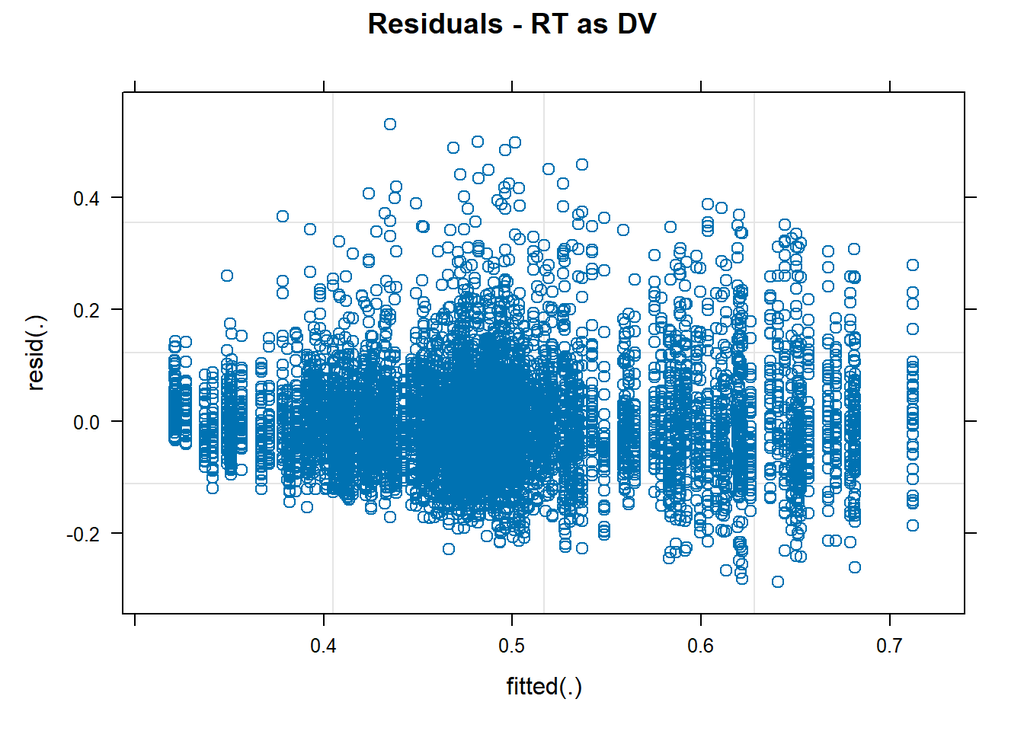

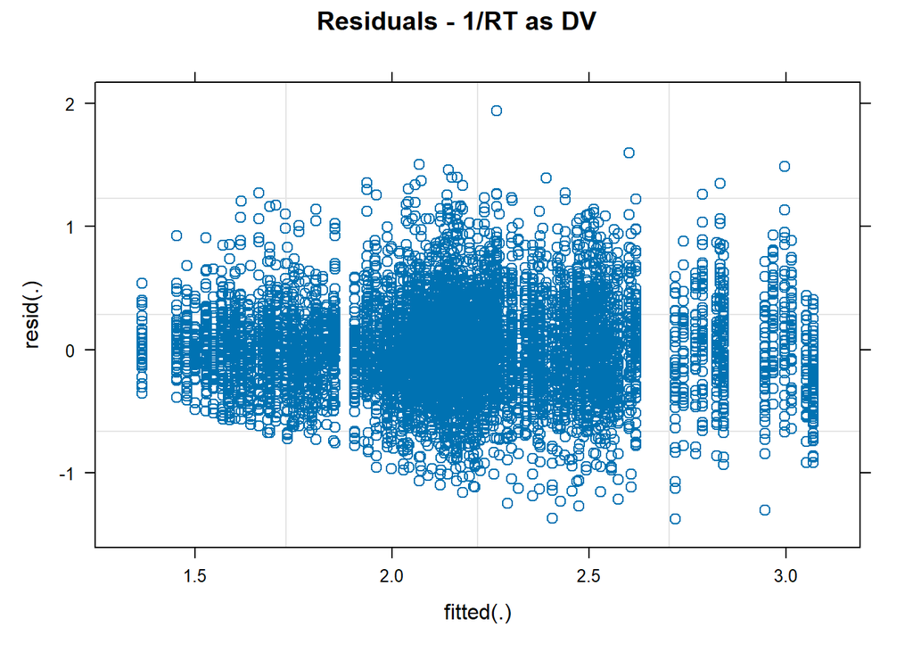

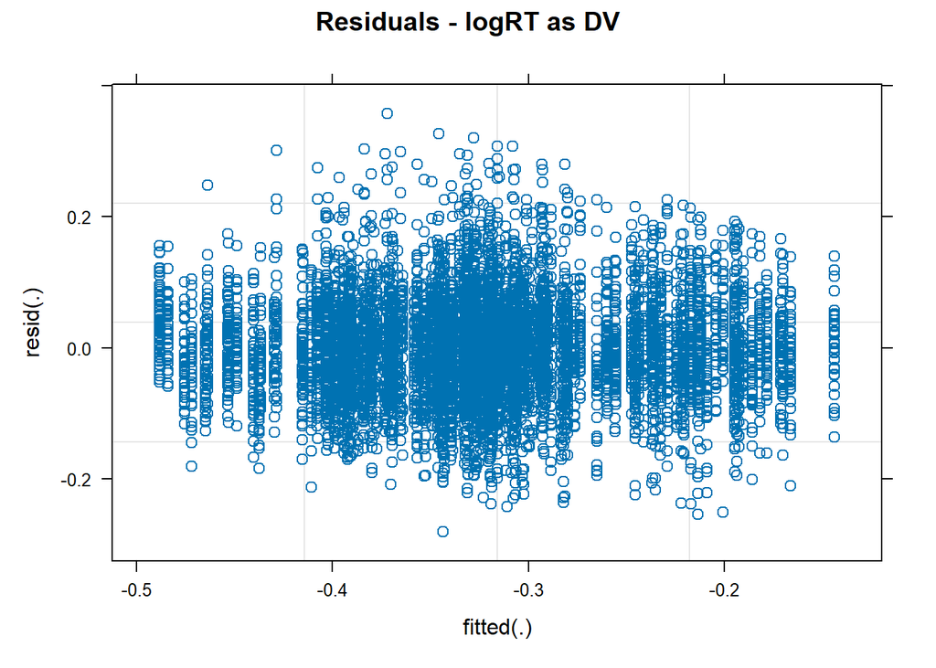

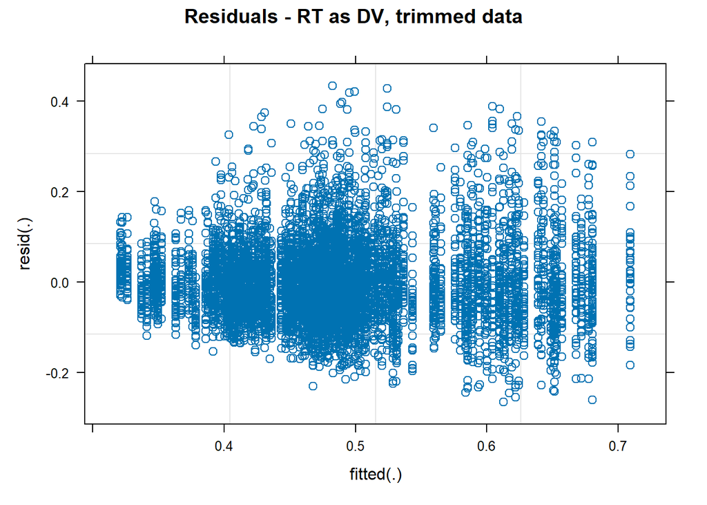

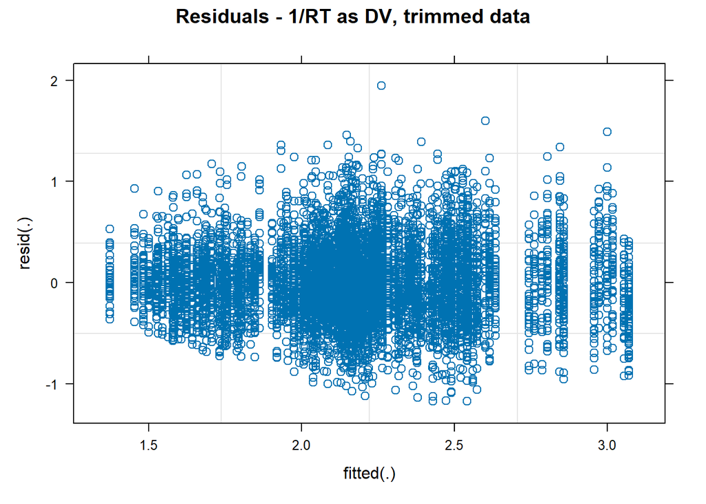

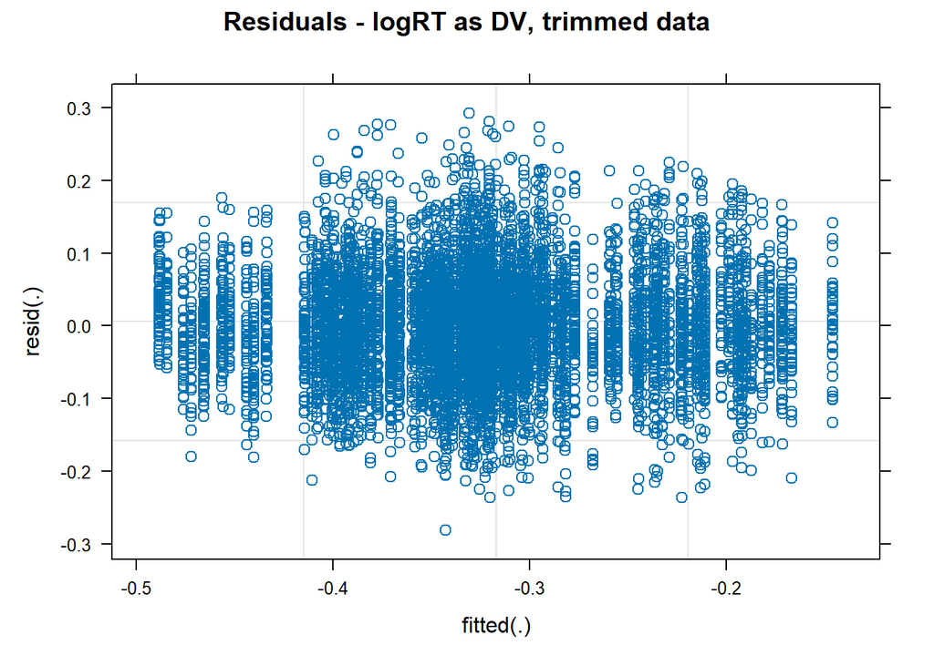

Não parece haver correlação importante entre os valores ajustados e os resíduos. No geral, os dados se comportam melhor para logRT, independentemente de haver ou nãl limpeza de dados.

Considerando tudo isso, escolhemos como variável dependente logRT, e utilizamos o dataset com limpeza de dados altamente influentes.

# 2. Encontrar máxima estrutura que convirja

Aqui, encontrar a estrutura máxima do modelo que convirja. Há uma série de algoritmos para isso, incluindo a heurística “keep it maximal” de Barr et al. (2013) e variações. Neste experimento, utilizamos o pacote buildmer (Voeten 2022), que automatiza esse processo. Em outro documento, comparamos o desempenho do buildmer com as heurísticas manuais e observamos que os resultados são qualitativamente idênticos.

```r
trimlogfplmm1 <- buildmer(formula = logRT ~ foreperiod*condition*oneBackFP +
                    (1+foreperiod*condition*oneBackFP|participant),
                  data = data2,
                  buildmerControl = list(crit = "LRT",
                                         family = gaussian(link = "identity"),
                                         include = 'foreperiod*condition*oneBackFP',
                                         calc.anova = TRUE))
```

```
##       grouping                           term
## 1         <NA>                     foreperiod
## 2         <NA>                      condition
## 3         <NA>           foreperiod:condition
## 4         <NA>                      oneBackFP
## 5         <NA>           foreperiod:oneBackFP
## 6         <NA>            condition:oneBackFP
## 7         <NA> foreperiod:condition:oneBackFP
## 8         <NA>                              1
## 9  participant                              1
## 10 participant                     foreperiod
## 11 participant                      condition
## 12 participant           foreperiod:condition
## 13 participant                      oneBackFP
##                                  block       score Iteration          LRT
## 1                                 <NA>          NA         1           NA
## 2                                 <NA>          NA         1           NA
## 3                                 <NA>          NA         1           NA
## 4                                 <NA>          NA         1           NA
## 5                                 <NA>          NA         1           NA
## 6                                 <NA>          NA         1           NA
## 7                                 <NA>          NA         1           NA
## 8                              NA NA 1          NA         1           NA
## 9                     NA participant 1        -Inf         1           NA
## 10           NA participant foreperiod  -25.497997         1           NA
## 11            NA participant condition -169.479822         1           NA
## 12 NA participant foreperiod:condition   -7.918693         1 0.0004646264
## 13            NA participant oneBackFP   -5.524719         1 0.0039869892
```

```r
formula(trimlogfplmm1)
```

```
## logRT ~ 1 + foreperiod + condition + foreperiod:condition + oneBackFP +
##     foreperiod:oneBackFP + condition:oneBackFP + foreperiod:condition:oneBackFP +
##     (1 + foreperiod + condition + foreperiod:condition + oneBackFP |
##         participant)
```

```r
isSingular(trimlogfplmm1)
```

```
## [1] FALSE
```

# 3. Selecionar variável dependente utilizando estrutura encontrada acima

```r
trimfplmm1 <- mixed(formula =  RT ~ 1 + foreperiod*condition*oneBackFP +
                      (1 + foreperiod + condition + foreperiod:condition + oneBackFP | participant),
                    data = data,
                    control = lmerControl(optimizer = c("bobyqa"),optCtrl=list(maxfun=2e5),calc.derivs = FALSE),
                    progress = TRUE,
                    expand_re = TRUE,
                    method =  'S',
                    REML=TRUE,
                    return = "merMod")

isSingular(trimfplmm1)
```

```
## [1] FALSE
```

```r
triminvfplmm1 <- mixed(formula =  invRT ~ 1 + foreperiod*condition*oneBackFP +
                      (1 + foreperiod + condition + foreperiod:condition + oneBackFP | participant),
                    data = data,
                    control = lmerControl(optimizer = c("bobyqa"),optCtrl=list(maxfun=2e5),calc.derivs = FALSE),
                    progress = TRUE,
                    expand_re = TRUE,
                    method =  'S',
                    REML=TRUE,
                    return = "merMod")

isSingular(triminvfplmm1)
```

```
## [1] TRUE
```

```r
trimlogfplmm1 <- mixed(formula =  logRT ~ 1 + foreperiod*condition*oneBackFP +
                      (1 + foreperiod + condition + foreperiod:condition + oneBackFP | participant),
                    data = data,
                    control = lmerControl(optimizer = c("bobyqa"),optCtrl=list(maxfun=2e5),calc.derivs = FALSE),
                    progress = TRUE,
                    expand_re = TRUE,
                    method =  'S',
                    REML=TRUE,
                    return = "merMod")

isSingular(trimlogfplmm1)
```

```
## [1] FALSE
```

Apenas os modelos com RT e logRT convergem, então comparamos apenas esses. Primeiro, a distribuição de resíduos.

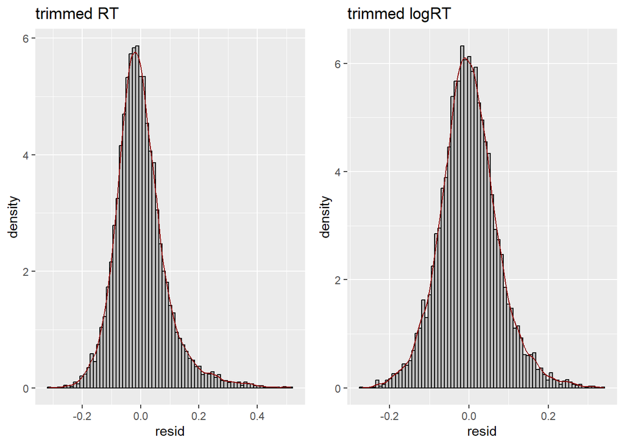

| stat | RT | trim log(RT) |
| --- | --- | --- |
| $R^2_m$ | 0.0236 | 0.0225 |
| $R^2_c$ | 0.4819 | 0.5042 |
| $R^2_{qq}$ | 0.9473 | 0.9902 |

# References

Barr, Dale J., Roger Levy, Christoph Scheepers, and Harry J. Tily. 2013. “Random Effects Structure for Confirmatory Hypothesis Testing: Keep It Maximal.” *Journal of Memory and Language* 68 (3): 255–78. https://doi.org/10.1016/j.jml.2012.11.001.

Voeten, Cesko C. 2022. *Buildmer: Stepwise Elimination and Term Reordering for Mixed-Effects Regression*. https://CRAN.R-project.org/package=buildmer.